# Project 1: Investigating Data For No Show Medical Appointments

### Investigating Further To See If Data Needs Cleaned.

```python
# We have already checked for Null Values and that each Column has a matching amount of rows. Now we will check for duplicates.

print(df.duplicated().sum())
```

```
0
```

> **Data Check 5:** *According to the above there are no duplicates in our dataset.*

Earlier when we viewed the summary of our data we saw that the minumum age value for age was -1.0 which can not be correct. To confirm this we should view these columns.

```python
# View the columns where age is less than 0.

df[df["Age"] < 0]
```

|  | PatientId | AppointmentID | Gender | ScheduledDay | AppointmentDay | Age | Neighbourhood | Scholarship | Hipertension | Diabetes | Alcoholism | Handcap | SMS_received | No-show |
| --- | --- | --- | --- | --- | --- | --- | --- | --- | --- | --- | --- | --- | --- | --- |
| 99832 | 4.659432e+14 | 5775010 | F | 2016-06-06T08:58:13Z | 2016-06-06T00:00:00Z | -1 | ROMÃO | 0 | 0 | 0 | 0 | 0 | 0 | No |

> **Data Check 6:** *Although a patient could be 0, a baby brought in my their parent, it is impossible for any child to have an age less than 0. Checking the data we can see, as shown above, one such entry which shows the patient as having an age of -1*.

### Data Cleaning

**Fixing Column Labels**

```python
# Fixing misspellings and missing Capitalisations.

df.rename(columns={'Hipertension':'Hypertension', 'Handcap':'Handicap',
                    'SMS_received':'SMS_Received', 'No-show':'No_Show'}, inplace = True)
```

```python
df.head(1)
```

|  | PatientId | AppointmentID | Gender | ScheduledDay | AppointmentDay | Age | Neighbourhood | Scholarship | Hypertension | Diabetes | Alcoholism | Handicap | SMS_Received | No_Show |
| --- | --- | --- | --- | --- | --- | --- | --- | --- | --- | --- | --- | --- | --- | --- |
| 0 | 2.987250e+13 | 5642903 | F | 2016-04-29T18:38:08Z | 2016-04-29T00:00:00Z | 62 | JARDIM DA PENHA | 0 | 1 | 0 | 0 | 0 | 0 | No |

> **Data Fix 1** We have now corrected the simpliest issue by fixing the spelling and formating of the Column Headings.

**Create Masks for the No_Show Data**

```python
# As mentioned earlier we will not convert the Yes and No of the No_Show Column into numbers. Missed = Yes & Arrived = No

Missed = df.No_Show == 'Yes'
Arrived = df.No_Show == 'No'
```

```python
df.Hypertension[Missed].mean()
```

```
0.16900398763385457
```

```python
df.Hypertension[Arrived].mean()
```

```
0.20439189189189189
```

```python
df.Hypertension.mean()
```

```
0.19724592181096021
```

> **Data Fix 2:** We have now created the masks and tested them by running the mean of the Hypertension with the Arrived and Missed numbers for the those who showed up and did not show up for their appointments.

**Fixing Ages Less Than 0**

Since we know that there is only one row of data which has this value we can safely just remove it without damaging the overall integrity of the data.

```python
df = df[df.Age != -1]

# Solution located at - https://stackoverflow.com/questions/18172851/deleting-dataframe-row-in-pandas-based-on-column-value
```

```python
df.shape
```

```
(110526, 14)
```

We can now see that the df.shape shows one less row than originally.

```python
# Let us run the earlier line of code to look for any rows with a value of less than 0.

df[df["Age"] < 0]
```

|  | PatientId | AppointmentID | Gender | ScheduledDay | AppointmentDay | Age | Neighbourhood | Scholarship | Hypertension | Diabetes | Alcoholism | Handicap | SMS_Received | No_Show |
| --- | --- | --- | --- | --- | --- | --- | --- | --- | --- | --- | --- | --- | --- | --- |

> **Data Fix 3:** We have now removed the one row of incorrect data that we located earlier.

**Converting ScheduledDay & AppointmentDay values to Date & Time Datatypes**

```python
## Referencing method from = https://datatofish.com/strings-to-datetime-pandas/

df['ScheduledDay'] = pd.to_datetime(df['ScheduledDay'])
df['AppointmentDay'] = pd.to_datetime(df['AppointmentDay'])
```

```python
df.info()
```

```
<class 'pandas.core.frame.DataFrame'>
Int64Index: 110526 entries, 0 to 110526
Data columns (total 14 columns):
PatientId         110526 non-null float64
AppointmentID     110526 non-null int64
Gender            110526 non-null object
ScheduledDay      110526 non-null datetime64[ns]
AppointmentDay    110526 non-null datetime64[ns]
Age               110526 non-null int64
Neighbourhood     110526 non-null object
Scholarship       110526 non-null int64
Hypertension      110526 non-null int64
Diabetes          110526 non-null int64
Alcoholism        110526 non-null int64
Handicap          110526 non-null int64
SMS_Received      110526 non-null int64
No_Show           110526 non-null object
dtypes: datetime64[ns](2), float64(1), int64(8), object(3)
memory usage: 12.6+ MB
```

> **Data Fix 4:** We have no converted both ScheduledDay & AppointmentDay to the *datatime64* format.

**Data Cleansing Conclusion**

We have now fixed all the earlier identified issues and can move on to the Exploratory Data Analysis phase.

**Setting up my future Histograms**

```python
def myHistPlot(df,xVar,density=False):
    ...
    # The below will allow me to call my graphs much easier for data points.
    ...
    # plot
    df.loc[Arrived][xVar].hist(grid=False,bins=4,edgecolor='black',figsize=[14,8],label='Arrived',align='left',density=density)
    df.loc[Missed][xVar].hist(grid=False,bins=4,edgecolor='black',figsize=[14,8],label='Missed',align='right',density=density)
    # Add title and format it
    plt.title(f'Distribution of {xVar} by Show/NoShow'.title(),
              fontsize = 14, weight = "bold")
    # Add x label and format it
    plt.xlabel(xVar.title(),
              fontsize = 10, weight = "bold")
    # Add y label and format it
    plt.ylabel('Frequency'.title(),
              fontsize = 10, weight = "bold")
    # add tick labels
    # we know that the values will be 0/1 - where 0 means No
    tick_labels=[f'No {xVar}',f'{xVar}']
    plt.xticks([0.125,0.875],tick_labels);
```

## Exploratory Data Analysis

### Research Question 1: *Does Age Have A Noticable Influence On Paitents Who Miss Their Appointments*

*This question is important to ask as it would be easy to predict if a patient will make their appointment or not. It would even allow the individuals docotrs to potentially work schedules around patients of a certain age **if** age has a significant influence on attendance.*

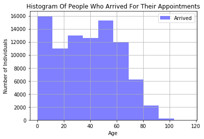

```python
# Does Age have a significant impact on whether or not the patient will show up for their appointment.

df.Age[Arrived].hist(alpha=0.5,label='Arrived', color='Blue')
plt.title("Histogram Of People Who Arrived For Their Appointments")
plt.xlabel("Age")
plt.ylabel("Number of Individuals")
plt.legend();
```

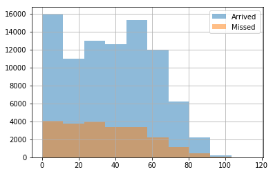

```python
df.Age[Arrived].hist(alpha=0.5,label='Arrived')
df.Age[Missed].hist(alpha=0.5,label='Missed')
plt.legend();
```

```python
# Average Age of the Data Set
print('Appointments Mean Age:{:.1f}'.format(df.Age.mean()))
print('Kept Appointments Mean Age:{:.1f}'.format(df[Arrived].Age.mean()))
print('Missed Appointments Mean Age:{:.1f}'.format(df[Missed].Age.mean()))
```

```
Appointments Mean Age:37.1
Kept Appointments Mean Age:37.8
Missed Appointments Mean Age:34.3
```

**Analysis of Data**

- We have looked at the distribution of the data when it comes to age vs attendance (both values for those who Arrived and Missed).
- We then checked the Mean Age of the Patients.
- The Mean Age of the Patients who kept their Appointments.
- The Mean Age of those who missed their Appointments.

**Observations**

*Arrived*

We can see from the above histograms that for those patients who kept their appointments that the data has two peaks making it a Biomdal Distribution peaking at both 0 ages old and 55 years old.

*Missed* Meanwhile the missed appointments, when looked at against age, also peak in two places. Once at 0 years old, which matches with the arrived peak, but the second peak is much sooner being at around 25-30 years old.

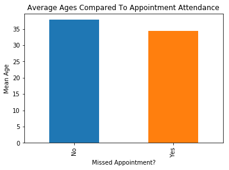

```python
# Bar Graph

df.groupby('No_Show').Age.mean().plot(kind='bar')
plt.title("Average Ages Compared To Appointment Attendance")
plt.xlabel("Missed Appointment?")
plt.ylabel("Mean Age");
```

**Conclusion**

From here we can see that the average person who misses an appointment is likely to be younger than those who will make the appointment. We see that the average age of those who missed their appointment was *34.3 years old* and the average age for those who did attend their appointment was *37.8 years old*.

I personally do not believe this is a significant enough pattern however to really help doctor officers to plan around predicted missed appointments, at least not with the data we currently have.

In this case it might be useful to have more data as with 100K we are only looking 0.0005% of the population. Although I believe we would also need more tools and a better understanding of statistics than we have learnt so far in this module to better look at the data.

### Research Question 2: *What % Overall Of People Attended Their Appointment*

*This is an important question to ask as following questions will rely on this information for looking at alongside the average to see how it compares.*

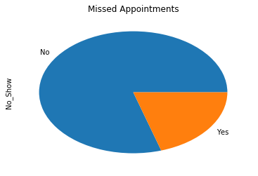

```python
df.No_Show.value_counts().plot(kind='pie')
plt.title("Missed Appointments");
```

```python
# The Following 2 Steps are from - https://dfrieds.com/data-analysis/value-counts-python-pandas.html
```

```python
df['No_Show'].value_counts(ascending=True)
```

```
Yes    22319
No     88207
Name: No_Show, dtype: int64
```

```python
df['No_Show'].value_counts(normalize=True)
```

```
No     0.798066
Yes    0.201934
Name: No_Show, dtype: float64
```

**Analysis**

- We created a pie chart to create a visual summary of the data.
- We checked the values of No Show Data.
- We checked the % of the No Show Data.
- *Note: Yes means they missed the appointment and No means they got to their appointment.*

**Conclusion**

This shows us that 79.8% of those who make appointments attend them whilst 20.2% missed their appointments.

This on it's own isn't very useful but can be for later comparisons.

### Research Question 3: *Are Patients On Scholarship Less Likely To Miss An Appointment?*

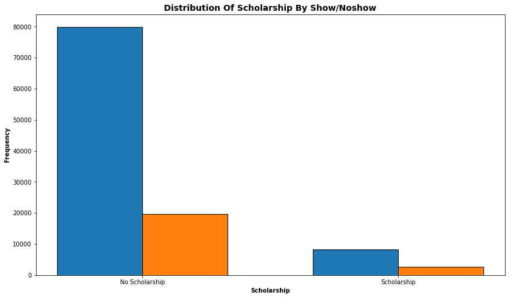

```python
# calling plot function for scholarship data
myHistPlot(df,'Scholarship')
```

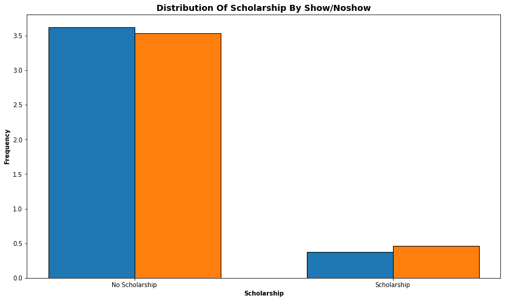

```python
#same as above but with relative frequency
myHistPlot(df,'Scholarship', density=True)
```

```python
df['Scholarship'].value_counts(ascending=True)
```

```
1    10861
0    99665
Name: Scholarship, dtype: int64
```

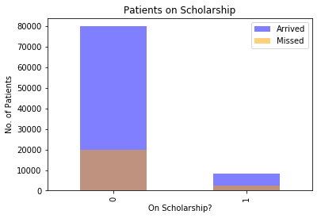

```python
#Another graph with slightly different formating, showing the same data, but just giving another angle to look at.
df.Scholarship[Arrived].value_counts().plot(kind='bar', alpha=0.5, color='blue', label='Arrived')
df.Scholarship[Missed].value_counts().plot(kind='bar', alpha=0.5, color='Orange', label='Missed')
plt.title("Patients on Scholarship")
plt.xlabel("On Scholarship?")
plt.ylabel("No. of Patients")
plt.legend();
```

```python
df.Scholarship[Arrived].value_counts(ascending=True)
```

```
1     8283
0    79924
Name: Scholarship, dtype: int64
```

```python
df.Scholarship[Missed].value_counts(ascending=True)
```

```
1     2578
0    19741
Name: Scholarship, dtype: int64
```

**Analysis**

- The main datasets we're looking at here are those on scholarship who missed their appointments and those who did not. We will also, visually, compare this to the same data of those not on the scholarship so that we have an idea
- First we look at a histogram to get a general idea of the comparison between the two data sets.
- Then we look at a bar graph of the No Shows of the Scholarship Data.
- Then we look at a comparative bar graph with the Scholarship Data and their proportions of arrived and missed figures.
- After this we got the exact values of those who arrived and those who missed their appointments.
- The above values allow us to very quickly get the percentage's for arrived & missed which we can easily compare to the values from the overall data set to see if those on the Scholarship have a higher chance of missing their appointment or not.

**Conclusion**

From the above we can see that of the 10,861 (8,283+2,578) of the Patients who are on the Scholarship only 8,283 made their appointment. This means that nearly *24%* (almost a quarter) didn't attend their appointments which is higher than the average of *21%* despite one would usually think that those on a Welfare program would make the effort to attend to take advantage of this program.

### Research Question 4: *Do Medical Conditions Affect Attendance?*

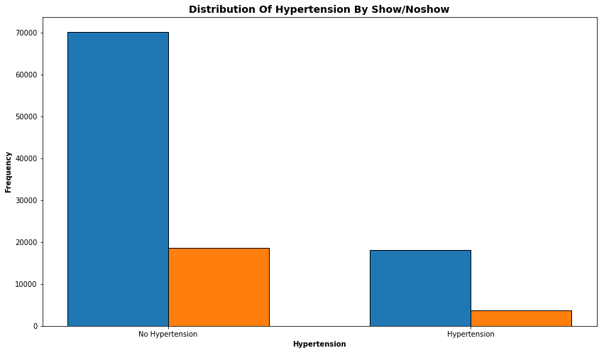

```python
# Calling plot function for Hypertension
myHistPlot(df,'Hypertension')
```

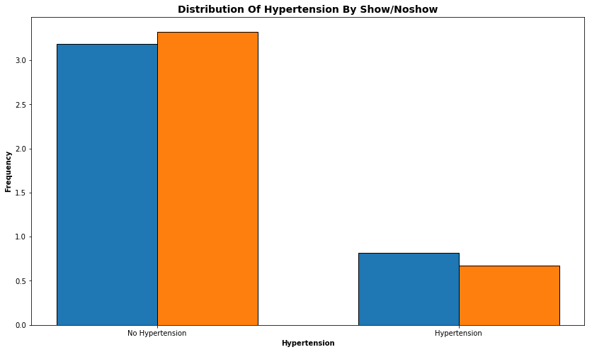

```python
# Same as above but with relative frequencies
myHistPlot(df,'Hypertension', density =True)
```

```python
df.Hypertension[Missed].value_counts(ascending=True)
```

```
1     3772
0    18547
Name: Hypertension, dtype: int64
```

```python
df.Hypertension[Arrived].value_counts(ascending=True)
```

```
1    18029
0    70178
Name: Hypertension, dtype: int64
```

```python
df.Hypertension.value_counts(ascending=True)
```

```
1    21801
0    88725
Name: Hypertension, dtype: int64
```

```python
(18029/21801)*100
```

```
82.69804137424889
```

```python
(3772/21801)*100
```

```
17.301958625751112
```

**Analysis**

- The main data we're looking at here are those on suffering from Hypertension who missed their appointments and those who did not.
- First we look at a comparative bar graph with the Hypertension Data and their proportions of arrived and missed figures.
- After this we got the exact values of the Hypertension dataset then those who arrived and those who missed their appointments.
- The above values allow us to very quickly get the percentage's for arrived & missed which we can easily compare to the values from the overall data set to see if those suffering from Hypertension have a higher chance of missing their appointment or not.

**Hypertension Observations:** Of a total of 21,801 patients with Hypertension we can see that 18,029 *(83%)* attended their appointment while 3,772 *(17%)* did not. This is a higher level of attendance than the average *(79%)*.

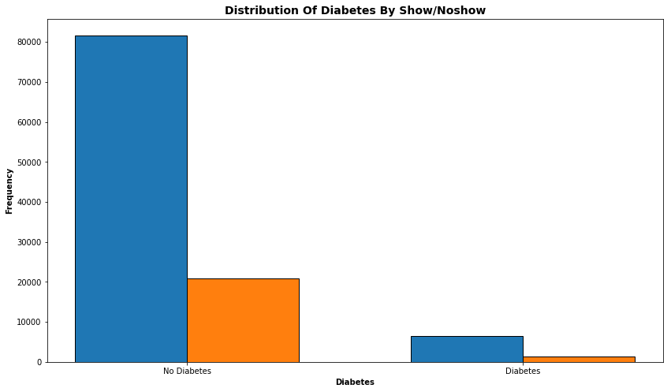

```python
# Calling plot function for Diabetes data
myHistPlot(df,'Diabetes')
```

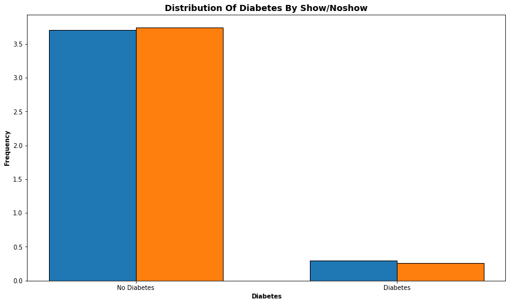

```python
# same as above but with relative frequencies
myHistPlot(df,'Diabetes', density="True")
```

```python
df.Diabetes[Missed].value_counts(ascending=True)
```

```
1     1430
0    20889
Name: Diabetes, dtype: int64
```

```python
df.Diabetes[Arrived].value_counts(ascending=True)
```

```
1     6513
0    81694
Name: Diabetes, dtype: int64
```

```python
df.Diabetes.value_counts(ascending=True)
```

```
1      7943
0    102583
Name: Diabetes, dtype: int64
```

```python
(6513/7943)*100
```

```
81.99672667757774
```

```python
(1430/7943)*100
```

```
18.00327332242226
```

**Analysis**

- The main data we're looking at here are those on suffering from Diabetes who missed their appointments and those who did not.
- First we look at a comparative bar graph with the Diabetes Data and their proportions of arrived and missed figures.
- After this we got the exact values of the Diabetes dataset then those who arrived and those who missed their appointments.
- The above values allow us to very quickly get the percentage's for arrived & missed which we can easily compare to the values from the overall data set to see if those suffering from Diabetes have a higher chance of missing their appointment or not.

**Diabetes Observation:** Of the 7,943 patients suffering from Diabetes we can see that *82%* attend their appointments whilst *18%* missed their appointment. Like the previous medical condition this is lower than the average.

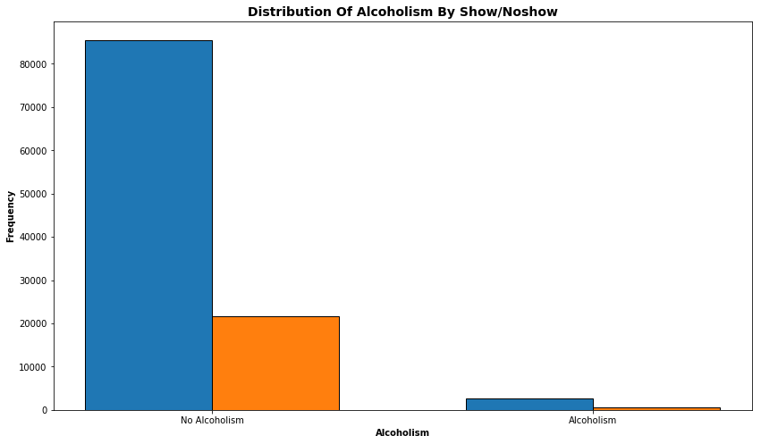

```python
# Calling plot function for Alcoholism data
myHistPlot(df,'Alcoholism')
```

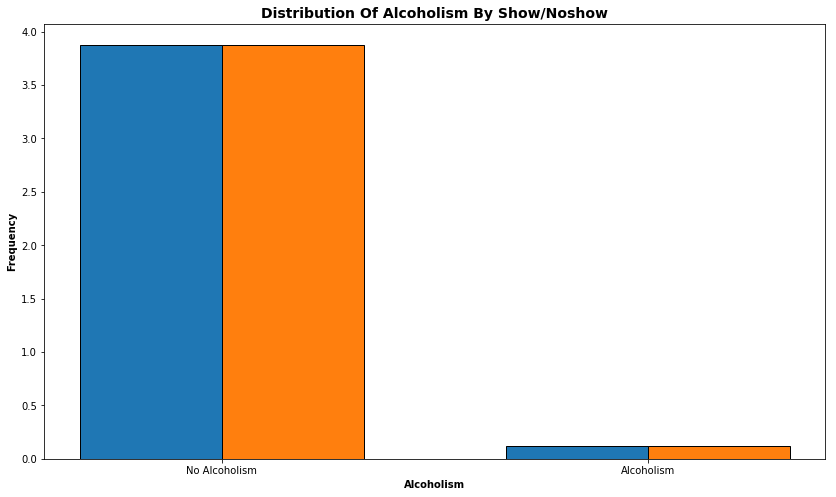

```python
# same as above but with relative frequency
myHistPlot(df,'Alcoholism', density ="True")
```

```python
df.Alcoholism[Missed].value_counts(ascending=True)
```

```
1      677
0    21642
Name: Alcoholism, dtype: int64
```

```python
df.Alcoholism[Arrived].value_counts(ascending=True)
```

```
1     2683
0    85524
Name: Alcoholism, dtype: int64
```

```python
df.Alcoholism.value_counts(ascending=True)
```

```
1      3360
0    107166
Name: Alcoholism, dtype: int64
```

```python
(2683/3360)*100
```

```
79.85119047619048
```

```python
(677/3360)*100
```

```
20.148809523809526
```

**Analysis**

- The main data we're looking at here are those on suffering from Alcoholism who missed their appointments and those who did not.
- First we look at a comparative bar graph with the Alcoholism Data and their proportions of arrived and missed figures.
- After this we got the exact values of the Alcoholism dataset then those who arrived and those who missed their appointments.
- The above values allow us to very quickly get the percentage's for arrived & missed which we can easily compare to the values from the overall data set to see if those suffering from Alcoholism have a higher chance of missing their appointment or not.

**Alcoholism Observation:** Of the 3360 patients suffering from Alcoholism we can see that *80%* attend their appointments whilst *20%* missed their appointment. This is only slightly better than the average *(79.85% vs 79.81%).*

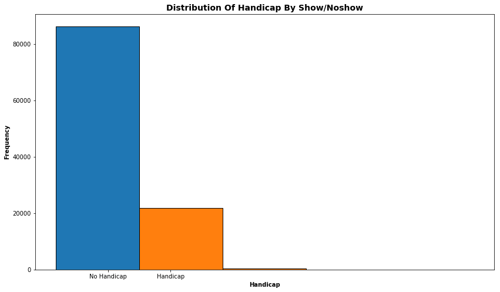

```python
# Note unlike the others the Handicap number ranges from 0 to 4. This is because it represents the number of disabilities
# that the patient has. I found a forum discussion discussing this:
# https://www.kaggle.com/joniarroba/noshowappointments/discussion/29699

#Calling data from Handicap with plot function
myHistPlot(df,'Handicap')
```

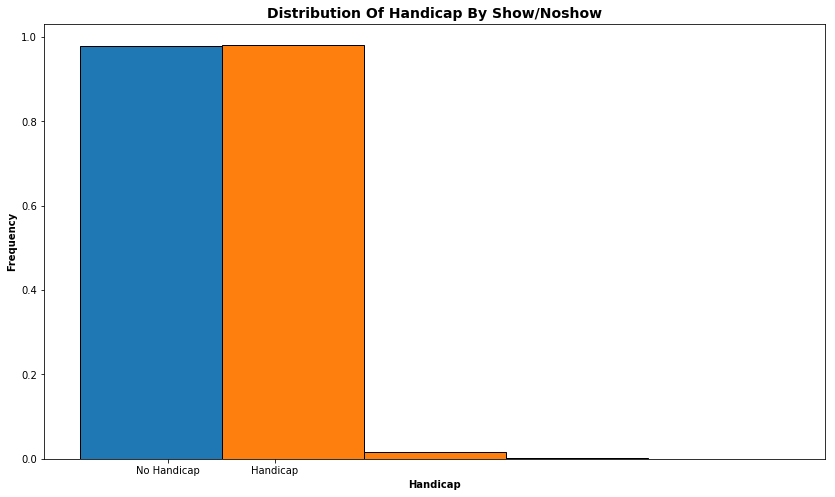

```python
# same as above but with relative freqency
myHistPlot(df,'Handicap', density="True")
```

```python
df.Handicap[Missed].value_counts(ascending=True)
```

```
4        1
3        3
2       37
1      366
0    21912
Name: Handicap, dtype: int64
```

```python
df.Handicap[Arrived].value_counts(ascending=True)
```

```
4        2
3       10
2      146
1     1676
0    86373
Name: Handicap, dtype: int64
```

```python
df.Handicap.value_counts(ascending=True)
```

```
4         3
3        13
2       183
1      2042
0    108285
Name: Handicap, dtype: int64
```

```python
Total_Handicap=3+13+183+2042
```

```python
Handicap_Missed=1+3+37+366
```

```python
Handicap_Arrived=2+10+146+1676
```

```python
(Handicap_Missed/Total_Handicap)*100
```

```
18.16153502900491
```

```python
(Handicap_Arrived/Total_Handicap)*100
```

```
81.83846497099509
```

**Analysis**

- The main data we're looking at here are those who have at least one disability who missed their appointments and those who did not.
- First we look at a comparative bar graph with the Handicap Data and their proportions of arrived and missed figures.
- After this we got the exact values of the Handicap dataset then those who arrived and those who missed their appointments.
- The above values allow us to very quickly get the percentage's for arrived & missed which we can easily compare to the values from the overall data set to see if those who have at least one disability have a higher chance of missing their appointment or not.

**Handicap Observation:** Of the 2,241 Patients with a disability of some sort we can see that *82%* attended their appointment whilst *18%* missed their appointment. Again this is a better attendance rate than the average.

### Research Question 5: *Does Sending a SMS Alert Improve Attendance?*

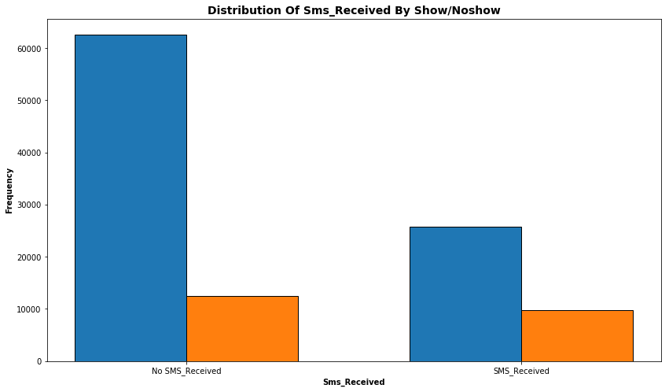

```python
# calling function for SMS_Recieved Data
myHistPlot(df,'SMS_Received')
```

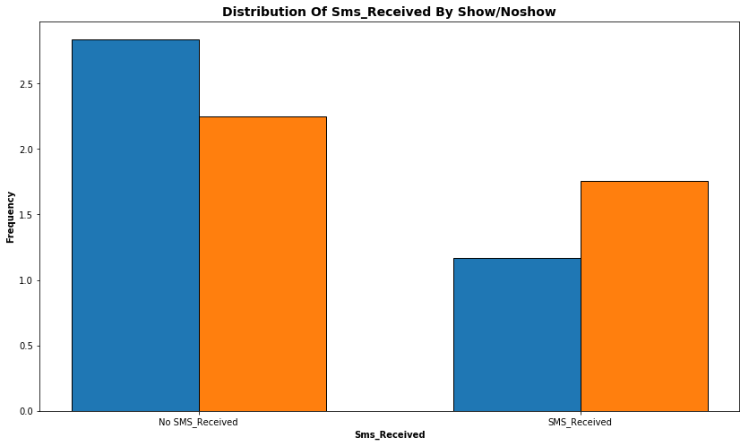

```python
myHistPlot(df,'SMS_Received', density="True")
```

```python
df.SMS_Received[Missed].value_counts(ascending=True)
```

```
1     9784
0    12535
Name: SMS_Received, dtype: int64
```

```python
df.SMS_Received[Arrived].value_counts(ascending=True)
```

```
1    25698
0    62509
Name: SMS_Received, dtype: int64
```

```python
df.SMS_Received.value_counts(ascending=True)
```

```
1    35482
0    75044
Name: SMS_Received, dtype: int64
```

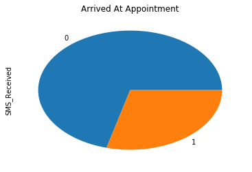

```python
df.SMS_Received[Arrived].value_counts().plot(kind='pie', title='Arrived At Appointment')
```

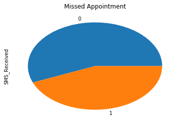

```python
df.SMS_Received[Missed].value_counts().plot(kind='pie', title='Missed Appointment')
```

```python
# % Arrived
(25698/35482)*100
```

```
72.425455160363
```

```python
# % Missed
(9784/35482)*100
```

```
27.574544839637
```

**Analysis**

- First we look at a histogram to get a general idea of the proportional amounts of people who arrived/missed their appointments who recieved the SMS text and those who did not.
- We then get the values for: Overall patient number who recieve the SMS Message, those who recieve the message & arrived and then those who recieve the message & missed.
- We then do two pie charts to get another easy to understand visualisation of how many proportionally arrived & missed their appointments who recieved SMS Messages compared to those who did not.
- We also got the % Arrived and the % Missed for those who recieved the SMS Message which we could compare against the overall data to see if the message helps with attendance or not.

**SMS Received Observations:** From the 35,482 patients who recieved a SMS Message we can see that 25,698 *(72%)* arrived to their appointment on time whilst 9,784 *(27%)* missed their appointment.

Shockingly this is a worst attendance record than the overall average despite the SMS received recieved by the patient.

## Conclusions

*Summary*

Our sample size included 100,000 different patients which I believe is a suitable amount of data for an analysis of this type as it allows us to look at the data as a whole *(e.g. looking at the mean values)* and be sure that the data is realtively accurate. We removed a single row due to an impossible value, that being the age = -1 patient, which will not impact the results of the analysis *(0.001% of the data was effected by this).*

We do not have the tools or data to make conclusive statements without certainty however we can use summary statistics to get answers to the questions we posed at the start of this report.

*Questions*

- 1. From looking at the ages we see a small, but notatble, difference between ages of those who attendaed their appointments and those who did not. The average age of a patient who keeps their appointment is 37.8 whilst the average age of the missed appointment is 34.3.
- 1. We know that, overall, 79.8% of those who make appointments attend them whilst 20.2% do not.
- 1. Surprisingly being on the Scholarship program does not guarantee better attendance, in fact we saw a lower than average attendance rate amongst this group with attendance dropping to 76%.
- 1. Perhaps unsurpisingly we saw that people with long-term illnesses have a noticably better attendance rate than the average patient. Hypertension saw 83% attendance; Diabetes was up at 82%; Alcoholism was sitting at 80% *(only 0.04% higher than the average when looked at to 2 decimal places)* and those suffering from 1 or more disabilities (Handicap Data) had an attendance rate of 82%.
- 1. To my surprise those patients who recieve SMS Messages have a significantly worst attendance rate than the average at only 72%. However without more data we can not say the reason for this as they may simply have signed up for this service due to having a history of poor attendance with their Doctor. *This is simply conjecture based of my local GP practice of giving those with poor attendance this service. Without more Data we can not make any true educated observations.*

## Submitting your Project

> Before you submit your project, you need to create a .html or .pdf version of this notebook in the workspace here. To do that, run the code cell below. If it worked correctly, you should get a return code of 0, and you should see the generated .html file in the workspace directory (click on the orange Jupyter icon in the upper left).

> Alternatively, you can download this report as .html via the **File** > **Download as** submenu, and then manually upload it into the workspace directory by clicking on the orange Jupyter icon in the upper left, then using the Upload button.

> Once you've done this, you can submit your project by clicking on the "Submit Project" button in the lower right here. This will create and submit a zip file with this .ipynb doc and the .html or .pdf version you created. Congratulations!

## OPTIONAL: Question for the reviewer

If you have any question about the starter code or your own implementation, please add it in the cell below.

For example, if you want to know why a piece of code is written the way it is, or its function, or alternative ways of implementing the same functionality, or if you want to get feedback on a specific part of your code or get feedback on things you tried but did not work.

Please keep your questions succinct and clear to help the reviewer answer them satisfactorily.

> What would be the cleverer way to show the percentages I did for the medical conditions?

> Just relisting sources referenced for clarity:
> - **Deleting Rows** - https://stackoverflow.com/questions/18172851/deleting-dataframe-row-in-pandas-based-on-column-value
> - **Converting String to Date** - https://datatofish.com/strings-to-datetime-pandas/
> - **Counting Unique Occurrences** - https://dfrieds.com/data-analysis/value-counts-python-pandas.html
> - **Finding Clarity on Handicap Data Meaning** - https://www.kaggle.com/joniarroba/noshowappointments/discussion/29699

```python
from subprocess import call
call(['python', '-m', 'nbconvert', 'Investigate_a_Dataset.ipynb'])
```

```
255
```